```python
from google.colab import drive
drive.mount('/content/drive')
```

# Weather Image Recognition

## Βαθιά Μάθηση - Εργασία

### Αλέξανδρος Τσιώλης | ΑΜ: 01758

Το dataset που χρησιμοποιήθηκε για την εργασία είναι το [Weather Image Recognition](https://www.kaggle.com/datasets/jehanbhathena/weather-dataset) που περιέχει εικόνες κατηγοριοποιημένες σε 11 κλάσεις που περιγράφουν καιρικές συνθήκες. Κάποια από τα ονόματα των κλάσεων είναι βροχή, χιόνι, ουράνιο τόξο, παγετός κτλ.

Στο site του dataset υπάρχει ένα notebook που κάνει classification με pretrained μοντέλα όπως το ResNet, το VGG19 και το Xception. Ακολουθούν τα αποτελέσματα τους:

[figure not shown]

```python
import glob
import os
import sklearn
import tensorflow.keras as keras
import seaborn as sns
import numpy as np
import matplotlib.pyplot as plt
import pandas as pd
import tensorflow as tf
from keras.callbacks import EarlyStopping
from sklearn.preprocessing import LabelBinarizer
from sklearn.model_selection import train_test_split
from sklearn.metrics import classification_report
from sklearn.metrics import confusion_matrix
```

## Preprocessing

Φορτώνω τις εικόνες από τον φάκελο που βρίσκονται όλες μαζί, χωρίς να τις αποθηκεύω. Κρατώντας μόνο τα labels τους, μπορώ να δείξω το συνολικό πλήθος των εικονών.

```python
directory_path = os.path.join(".", "drive/MyDrive/all")                         # Αρχικοποίηση μεταβλητής με την διαδρομή του dataset
filenames_in_directory = glob.glob(os.path.join(directory_path, "*"))           # Αρχικοποίηση μεταβλητής με τα ονόματα των αρχείων του dataset

num_of_images=len(filenames_in_directory)                                       # Αρχικοποίηση μεταβλητής με τον αριθμό των εικόνων του dataset
print("Αριθμός εικόνων: ", num_of_images)

labels = list()                                                                 # Αρχικοποίηση μεταβλητής με τις ετικέτες των εικόνων

for id_filename, filename in enumerate(filenames_in_directory):
    label=filename.split(os.sep)[-1].split("_")[0]                              # Αποθήκευση της ετικέτας κάθε εικόνας στην μεταβλητή label
    labels.append(label)
```

```
Αριθμός εικόνων:  6862
```

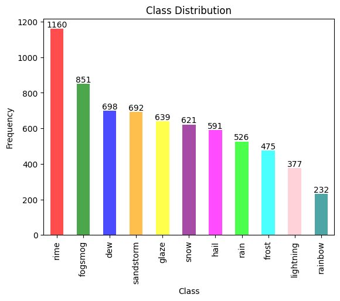

```python
df = pd.DataFrame(labels, columns=["labels"])
class_counts = df["labels"].value_counts()

colors=[ "red", "green","blue","orange","yellow","purple","magenta","lime","cyan","pink","teal"]

class_counts.plot(kind="bar", color=colors, alpha=0.7)

plt.xlabel("Class")
plt.ylabel("Frequency")
plt.title("Class Distribution")

# Add labels to the bars
for i, count in enumerate(class_counts):
    plt.text(i, count, str(count), ha="center", va="bottom")

plt.show()
```

Βλέποντας τα δεδομένα φαίνεται οτι κάποιες κλάσεις έχουν πολύ περισσότερες εικόνες από κάποιες άλλες. Για παράδειγμα, η κλάση rime έχει 1160 εικόνες, ενώ η κλάση rainbow έχει μόλις 232 εικόνες. Φαίνεται ότι τα δεδομένα είναι unbalanced. Για να τα κάνω balanced έχω κρατήσει μόνο 232 εικόνες από κάθε κλάση.

Οι εικόνες δεν έχουν όλες τις ίδιες διαστάσεις. Η μεταβλητή size θέτει τις διαστάσεις της κάθε εικόνας σε 128x128 μέσω της συνάρτησης "keras.preprocessing.image.load_img"

```python
size=128                                                                # Αρχικοποίηση μεταβλητής με το μέγεθος των εικόνων
```

Για να χρησιμοποιήσω το dataset έχω μετονομάσει τις εικόνες ανάλογα με την κατηγορία τους και τις έχω μεταφέρει σε ενα φάκελο από τον οποίο και τις παίρνω, όπως φαίνεται και στον παρακάτω κώδικα και τις αποθηκεύω σε ενα numpy array.

Για την κλάση της κάθε εικόνας παίρνω το όνομα της, κόβω ότι δεν χρειάζεται, και το αποθηκεύω σε μια λίστα.

```python
directory_path = os.path.join(".", "drive/MyDrive/balanced")                                # Αρχικοποίηση μεταβλητής με την διαδρομή του dataset
filenames_in_directory = glob.glob(os.path.join(directory_path, "*"))                       # Αρχικοποίηση μεταβλητής με τα ονόματα των αρχείων του dataset

num_of_images=len(filenames_in_directory)                                                   # Αρχικοποίηση μεταβλητής με τον αριθμό των εικόνων του dataset

images = np.zeros((num_of_images, size, size, 3))                                           # Αρχικοποίηση μεταβλητής με τις εικόνες του dataset
labels = list()                                                                             # Αρχικοποίηση μεταβλητής με τις ετικέτες των εικόνων
for id_filename, filename in enumerate(filenames_in_directory):
    label=filename.split(os.sep)[-1].split("_")[0]                                          # Αποθήκευση της ετικέτας κάθε εικόνας στην μεταβλητή label
    pill_img=keras.preprocessing.image.load_img(path=filename,                              # Αποθήκευση της εικόνας στην μεταβλητή pill_img
                                                color_mode="rgb",                           # για το preprocessing της εικόνας
                                                target_size=(size, size))
    images[id_filename,:,:,:]=keras.preprocessing.image.img_to_array(pill_img)              # Αποθήκευση της εικόνας στην μεταβλητή images
    labels.append(label)
print(f"The number of images is equal to {images.shape[0]}")
print(f"The shape of the array is: {images.shape}")
print(f"The data type of the array is: {images.dtype}")
```

```
The number of images is equal to 2552
The shape of the array is: (2552, 128, 128, 3)
The data type of the array is: float64
```

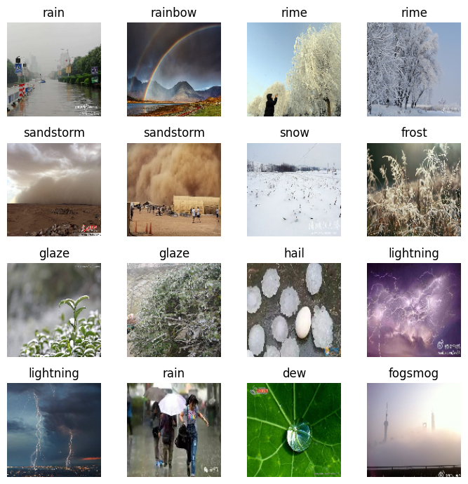

```python
fig, ax = plt.subplots(nrows = 4, ncols=4, figsize=(7, 7), squeeze=True)
cntr=1
for i in range(4):
    for j in range(4):
        ax[i,j].imshow(images[cntr]/255.0)
        ax[i,j].axis("off")
        ax[i,j].set_title(labels[cntr])
        cntr += 150
plt.tight_layout()
plt.show()
```

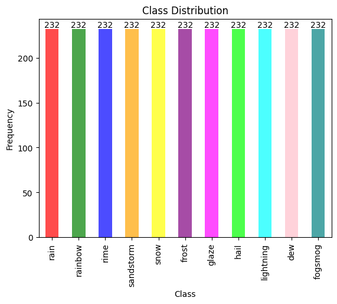

```python
df = pd.DataFrame(labels, columns=["labels"])
class_counts = df["labels"].value_counts()

class_counts.plot(kind="bar", color=colors, alpha=0.7)

plt.xlabel("Class")
plt.ylabel("Frequency")
plt.title("Class Distribution")

for i, count in enumerate(class_counts):
    plt.text(i, count, str(count), ha="center", va="bottom")

plt.show()
```

Ο τρόπος που θα επιχειρήσω να κάνω την κατηγοροποίηση των εικονών είναι ένα CNN.

Διαχωρίζω τις εικόνες σε test και train set με την εντολη "train_test_split".

Κρατάω 50 εικόνες από κάθε κλάση για να υπολογίσω την ακρίβρεια του νευρονικού μου και με τις υπόλοιπες το εκπαιδεύω.

```python
train_images, test_images, train_labels, test_labels = train_test_split(images, labels, test_size=0.21551724137, random_state=42, stratify=labels)
```

```python
print(f"The number of train images is equal to {train_images.shape[0]}")
print("The shape of the train images is:", train_images.shape)
print(f"The number of test images is equal to {test_images.shape[0]}")
print("The shape of the test images is:", test_images.shape)
print("The data type of the images is:", train_images.dtype)
```

```
The number of train images is equal to 2002
The shape of the train images is: (2002, 128, 128, 3)
The number of test images is equal to 550
The shape of the test images is: (550, 128, 128, 3)
The data type of the images is: float64
```

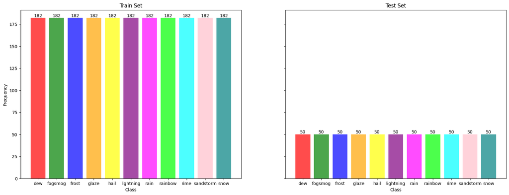

```python
unq_values_train, counts_train = np.unique(train_labels, return_counts=True)
unq_values_test, counts_test = np.unique(test_labels, return_counts=True)

fig, axis = plt.subplots(nrows=1, ncols=2, sharey=True, figsize=(20, 7))

axis[0].bar(unq_values_train, counts_train, align="center", alpha=0.7, color=colors)
axis[0].set_xlabel("Class")
axis[0].set_ylabel("Frequency")
axis[0].set_title("Train Set")

for i, count in enumerate(counts_train):
    axis[0].text(unq_values_train[i], count, str(count), ha='center', va='bottom')

axis[1].bar(unq_values_test, counts_test, align="center", alpha=0.7, color=colors)
axis[1].set_xlabel("Class")
axis[1].set_title("Test Set")

for i, count in enumerate(counts_test):
    axis[1].text(unq_values_test[i], count, str(count), ha='center', va='bottom')

plt.show()
```

Τα pixel των εικονών είναι RGB και παίρνουν τιμές από 0 έως 255.

Κάνω κανονικοποίηση διαιρώντας όλες τις τιμές με το 255. Έτσι οι τιμές των pixel θα κυμαίνονται απο 0 έως 1.

```python
print(f"Value interval of the train set before the min-max normalization:[{train_images.min()},{train_images.max()}]")
print(f"Value interval of the test set before the min-max normalization:[{test_images.min()},{test_images.max()}]")

train_images = train_images / 255.0                                # Κανονικοποίηση των εικόνων του train set
test_images = test_images / 255.0                                  # Κανονικοποίηση των εικόνων του test set

print(f"Value interval of the train set after the min-max normalization:[{train_images.min()},{train_images.max()}]")
print(f"Value interval of the test set after the min-max normalization:[{test_images.min()},{test_images.max()}]")
```

```
Value interval of the train set before the min-max normalization:[0.0,255.0]
Value interval of the test set before the min-max normalization:[0.0,255.0]
Value interval of the train set after the min-max normalization:[0.0,1.0]
Value interval of the test set after the min-max normalization:[0.0,1.0]
```

## Δημιουργία CNN

Δημιουργώ ενα CNN με την εξής μορφή:

**1. RandomTranslation**

- Τυχαία μετατόπιση των εικόνων εισόδου κατά ένα κλάσμα του ύψους και του πλάτους. Βοηθά στην εισαγωγή ποικιλίας στα δεδομένα εκπαίδευσης.

**2. RandomFlip**

- Τυχαία αναστροφή των εικόνων εισόδου οριζόντια. Προσθέτει ποικιλία στα δεδομένα εκπαίδευσης.

**3. RandomRotation**

- Τυχαία περιστροφή των εικόνων εισόδου. Αυξάνει την ποικιλία των δεδομένων.

**4. Conv2D #1**

- 32 φίλτρα με συνάρτηση ενεργοποίησης ReLU.
- Μέγεθος πυρήνα: 3x3.

**5. MaxPooling2D**

- Εκτελεί μέγιστη συσσώρευση, μειώνοντας τις χωρικές διαστάσεις της εικόνας εισόδου επιλέγοντας τη μέγιστη τιμή σε κάθε παράθυρο συσσώρευσης.
- Μέγεθος πυρήνα: 2x2.

**6. Conv2D #2**

- 64 φίλτρα με συνάρτηση ενεργοποίησης ReLU.
- Μέγεθος πυρήνα: 3x3.

**7. MaxPooling2D**

- Εκτελεί μέγιστη συσσώρευση στην έξοδο του προηγούμενου επιπέδου συνέλιξης.
- Μέγεθος πυρήνα: 2x2.

**8. Conv2D #3**

- 64 φίλτρα με συνάρτηση ενεργοποίησης ReLU.
- Μέγεθος πυρήνα: 3x3.

**9. Flatten**

- Αποτελεί την επίπεδη μετατροπή της έξοδου των προηγούμενων συνελικτικών επιπέδων σε ένα 1D διάνυσμα, προετοιμάζοντάς το για τα πλήρως συνδεδεμένα επίπεδα.

**10. Dropout**

- Τυχαία απενεργοποιεί ένα ποσοστό (0.3) των μονάδων εισόδου κατά τη διάρκεια της εκπαίδευσης.
- Βοηθά στην αποφυγή του overfitting.

**11. Dense #1**

- Πλήρως συνδεδεμένο (dense) επίπεδο με 64 νευρώνες και συνάρτηση ενεργοποίησης ReLU.

**12. Dense #2**

- Τελικό πλήρως συνδεδεμένο επίπεδο με 11 νευρώνες, αντίστοιχες στις 11 κλάσεις της ερασίας.
- Χρησιμοποιεί συνάρτηση ενεργοποίησης softmax για να εξάγει πιθανότητες για κάθε κλάση.

Συνολικά, αυτό το μοντέλο αποτελείται από συνελικτικά επίπεδα για την εξαγωγή χαρακτηριστικών, επίπεδα μέγιστης συσσώρευσης για τη μείωση των χωρικών διαστάσεων και πλήρως συνδεδεμένα επίπεδα για την ταξινόμηση. Οι τυχαίοι μετασχηματισμοί που εφαρμόζονται στην αρχή εισάγουν ποικιλία στα δεδομένα εκπαίδευσης, βελτιώνοντας έτσι την ικανότητα γενίκευσης του μοντέλου.

```python
kernel_size=(3,3)                                                                                   # Αποθήκευση των υπερπαραμέτρων του μοντέλου CNN
pooling_size=(2,2)
cnn_model = keras.models.Sequential([keras.layers.RandomTranslation(height_factor=(-0.2, 0.2),      # Δημιουργία του μοντέλου CNN
                                                                    width_factor=(-0.2, 0.2),       # με την χρήση των layers της βιβλιοθήκης keras
                                                                    fill_mode="nearest",            # Augmentation των εικόνων
                                                                    interpolation="bilinear"),
                                     keras.layers.RandomFlip(mode="horizontal"),
                                     keras.layers.RandomRotation(factor=(-0.2, 0.2),
                                                                 fill_mode="nearest",
                                                                 interpolation="bilinear"),
                                     keras.layers.Conv2D(filters=32,
                                                         kernel_size=kernel_size,
                                                         activation="relu",
                                                         input_shape=(size,size,3)),
                                     keras.layers.MaxPooling2D(pool_size=pooling_size),
                                     keras.layers.Conv2D(filters=64,
                                                        kernel_size=kernel_size,
                                                        activation="relu"),
                                     keras.layers.MaxPooling2D(pool_size=pooling_size),
                                     keras.layers.Conv2D(filters=64,
                                                        kernel_size=kernel_size,
                                                        activation="relu"),
                                     keras.layers.Flatten(),
                                     keras.layers.Dropout(rate=0.3),
                                     keras.layers.Dense(units=64,
                                                        activation="relu"
                                                       ),
                                     keras.layers.Dense(units=11,
                                                        activation="softmax"
                                                       )
                                    ]
                                   )
```

Ορίζω τη συνάρτηση απώλειας (loss function) ως κατηγορική απώλεια ("categorical_crossentropy"), τον "optimizer" ως "adam" και την ακρίβεια ("accuracy"). Αυτό καθορίζει τον τρόπο υπολογισμού της απώλειας κατά την εκπαίδευση του μοντέλου.

```python
cnn_model.compile(loss="categorical_crossentropy",                                          # Κάνω compile το μοντέλο με την χρήση του optimizer "adam"
                  optimizer="adam",                                                         # και της συνάρτησης κόστους "categorical_crossentropy"
                  metrics=["accuracy"]                                                      # Επιλέγω να παρακολουθώ την μετρική "accuracy"
                  )
cnn_model.build((None,size,size,3))
cnn_model.summary()
```

```
Model: "sequential_1"
_________________________________________________________________
 Layer (type)                Output Shape              Param #
=================================================================
 random_translation_1 (Rando  (None, 128, 128, 3)      0
 mTranslation)

 random_flip_1 (RandomFlip)  (None, 128, 128, 3)       0

 random_rotation_1 (RandomRo  (None, 128, 128, 3)      0
 tation)

 conv2d_3 (Conv2D)           (None, 126, 126, 32)      896

 max_pooling2d_2 (MaxPooling  (None, 63, 63, 32)       0
 2D)

 conv2d_4 (Conv2D)           (None, 61, 61, 64)        18496

 max_pooling2d_3 (MaxPooling  (None, 30, 30, 64)       0
 2D)

 conv2d_5 (Conv2D)           (None, 28, 28, 64)        36928

 flatten_1 (Flatten)         (None, 50176)             0

 dropout_1 (Dropout)         (None, 50176)             0

 dense_2 (Dense)             (None, 64)                3211328

 dense_3 (Dense)             (None, 11)                715

=================================================================
Total params: 3,268,363
Trainable params: 3,268,363
Non-trainable params: 0
_________________________________________________________________
```

```python
lb=LabelBinarizer()                                                     # Μετατροπή των labels σε binary vectors
train_labels=lb.fit_transform(train_labels)
test_labels=lb.fit_transform(test_labels)
print(train_labels.shape)
```

```
(2002, 11)
```

Στον παραπάνω κώδικα χρησιμοποιώ η κλάση "LabelBinarizer" από τη βιβλιοθήκη "sklearn.preprocessing" για τη μετατροπή των labels σε δυαδική κωδικοποιημένη μορφή. Ο πίνακας "train_labels" περιέχει τις ετικέτες κατά την εκπαίδευση, ενώ ο πίνακας "test_labels" περιέχει τις ετικέτες κατά την αξιολόγηση. Η συνάρτηση "fit_transform()" χρησιμοποιείται για την εφαρμογή της μετατροπής στα labels.

Στον παρακάτω κώδικα, η εκπαίδευση του μοντέλου γίνεται χρησιμοποιώντας τη GPU. Οι παράμετροι που περνάνε στη μέθοδο fit είναι οι εξής:

- train_images: Οι εικόνες εκπαίδευσης.
- train_labels: Οι ετικέτες εκπαίδευσης.
- epochs: Ο αριθμός των εποχών εκπαίδευσης.
- batch_size: Το μέγεθος των ομάδων παρατηρήσεων.
- validation_split: Το ποσοστό των δεδομένων που θα χρησιμοποιηθεί για επαλήθευση.
- callbacks: Λίστα με callbacks που θα εκτελεστούν κατά τη διάρκεια της εκπαίδευσης. Στο παράδειγμα παρουσιάζεται το callback EarlyStopping, το οποίο παρακολουθεί την val_loss και σταματά την εκπαίδευση αν δεν παρουσιαστεί βελτίωση για ένα συγκεκριμένο αριθμό εποχών (παράμετρος patience) και αποθηκεύει τα βέλτιστα βάρη του μοντέλου (restore_best_weights=True).

```python
with tf.device('/device:GPU:0'):
  history = cnn_model.fit(train_images,
                        train_labels,
                        epochs=200,
                        batch_size=128,
                        validation_split=0.2,
                        callbacks=[keras.callbacks.EarlyStopping(monitor="val_loss",patience=30,restore_best_weights=True)],
                        verbose=0
                        )
```

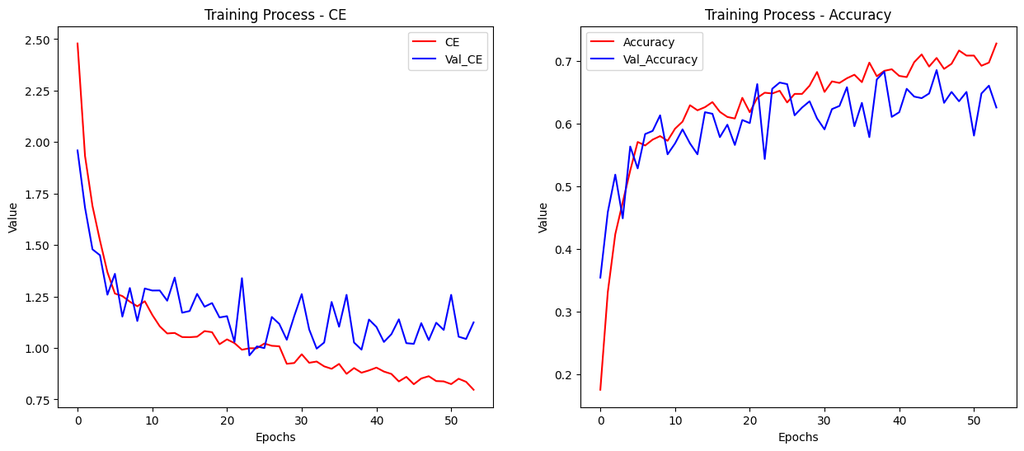

```python
fig, axis = plt.subplots(nrows=1,ncols=2, figsize=(15,6))

axis[0].plot(history.epoch, history.history['loss'], color="red")
axis[0].plot(history.epoch, history.history['val_loss'], color="blue")
axis[0].set_xlabel("Epochs")
axis[0].set_ylabel("Value")
axis[0].legend(["CE", "Val_CE"])
axis[0].set_title("Training Process - CE")

axis[1].plot(history.epoch, history.history['accuracy'], color="red")
axis[1].plot(history.epoch, history.history['val_accuracy'], color="blue")
axis[1].set_xlabel("Epochs")
axis[1].set_ylabel("Value")
axis[1].legend(["Accuracy", "Val_Accuracy"])
axis[1].set_title("Training Process - Accuracy")
plt.show()
```

## Αποτελέσματα

```python
test_pred=cnn_model.predict(test_images)                                # Προβλέπω τις κλάσεις των εικόνων του test set
test_pred=np.argmax(test_pred,axis=1)                                   # Μετατρέπω τις προβλέψεις σε αριθμούς
test_labels=np.argmax(test_labels,axis=1)                               # Μετατρέπω τα labels σε αριθμούς
```

```python
class_names = ['dew', 'fogsmog', 'frost', 'glaze', 'hail', 'lightning', 'rain', 'rainbow', 'rime', 'sandstorm', 'snow']
```

```python
# Αποθηκεύω το classification report σε ένα dictionary για να το χρησιμοποιήσω στη δημιουργία των παρακάτω γραφημάτων
report_dict = classification_report(test_labels, test_pred, target_names=class_names, output_dict=True)
```

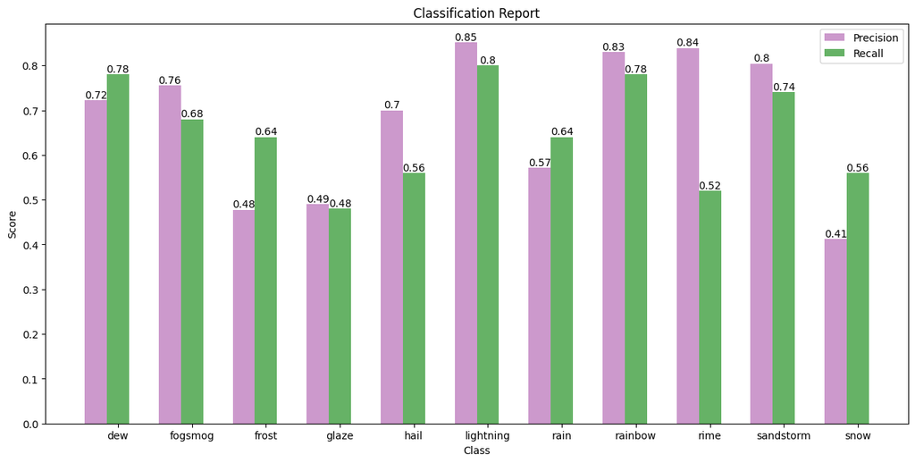

```python
precision = [report_dict[label]['precision'] for label in class_names]                      # Αποθηκεύω τις τιμές των μετρικών precision, recall και f1-score
recall = [report_dict[label]['recall'] for label in class_names]                            # για κάθε κλάση σε έναν πίνακα
f1_score = [report_dict[label]['f1-score'] for label in class_names]

x = range(len(class_names))                                                                 # Ορίζω τον άξονα x του γραφήματος
width = 0.3                                                                                 # Ορίζω το πλάτος των μπαρών του γραφήματος

fig, ax = plt.subplots(figsize=(15,7))
ax.bar(x, precision, width, label='Precision', color="purple", alpha=0.4)
ax.bar([i + width for i in x], recall, width, label='Recall', color="green", alpha=0.6)

ax.set_xticks([i + width for i in x])
ax.set_xticklabels(class_names)

ax.set_xlabel('Class')
ax.set_ylabel('Score')
ax.set_title('Classification Report')
ax.legend()

for i in x:
    ax.text(i, precision[i], str(round(precision[i], 2)), ha='center', va='bottom')
    ax.text(i + width, recall[i], str(round(recall[i], 2)), ha='center', va='bottom')

plt.show()
```

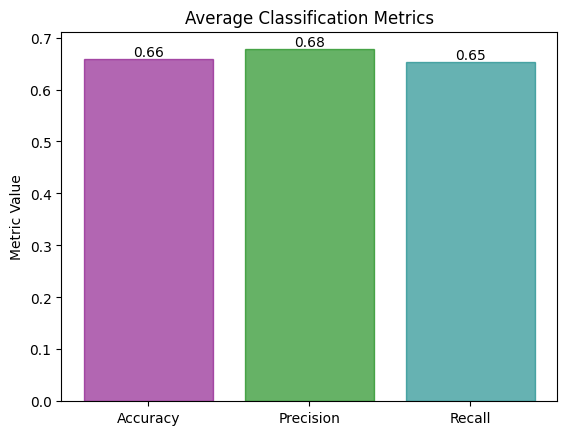

```python
# Obtain the weighted and macro averages from the classification report dictionary
weighted_avg = report_dict['weighted avg']
macro_avg = report_dict['macro avg']

# Extract precision, recall, and F1-score for weighted and macro averages
precision = weighted_avg['precision']
recall = weighted_avg['recall']
f1_score = weighted_avg['f1-score']
# Define the values
metrics = ['Accuracy', 'Precision', 'Recall']
values = [f1_score, precision, recall]

# Plot the bar chart
fig, ax = plt.subplots()
bars = ax.bar(metrics, values, alpha= 0.6)

# Add value labels to each bar
for bar in bars:
    yval = bar.get_height()
    ax.text(bar.get_x() + bar.get_width() / 2, yval, round(yval, 2), ha='center', va='bottom')

# Customize the colors of the bars
colors = ['purple', 'green', 'teal']
for bar, color in zip(bars, colors):
    bar.set_color(color)


# Set the plot title and labels
plt.title('Average Classification Metrics')
plt.ylabel('Metric Value')

# Display the plot
plt.show()
```

Συνολικά, τα αποτελέσματα δείχνουν ότι το μοντέλο επιδεικνύει αξιοπρεπή απόδοση, αλλά μπορεί να επωφεληθεί από περαιτέρω βελτιώσεις για καλύτερα αποτελέσματα στις κατηγορίες με τα χαμηλότερα σκορ.

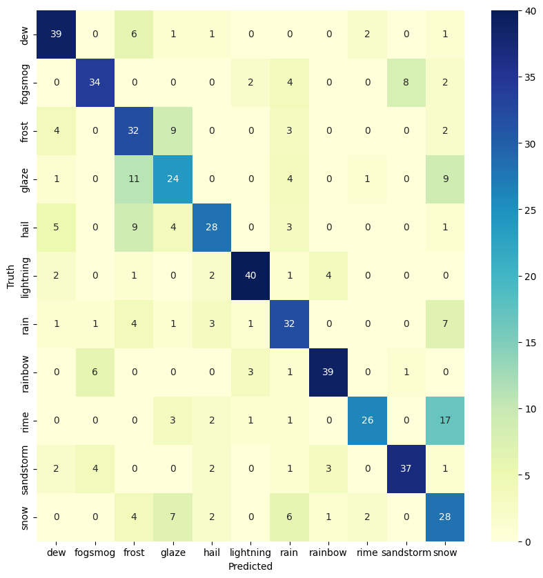

```python
cm=confusion_matrix(test_labels,test_pred)                                                      # Υπολογίζω το confusion matrix
plt.figure(figsize=(10,10))
test=sns.diverging_palette(250, 30, as_cmap=True)
sns.heatmap(cm,annot=True,xticklabels=class_names, yticklabels=class_names, cmap="YlGnBu")      # Και το εμφανίζω
plt.xlabel('Predicted')
plt.ylabel('Truth')

plt.show()
```

```python
wrong_predictions = []                                                           # Αποθηκεύω τις λάθος προβλέψεις σε έναν πίνακα
cor_preds=[]                                                                     # Αποθηκεύω τα σωστά labels σε έναν πίνακα
wrong_images=[]                                                                  # Αποθηκεύω τις εικόνες που αντιστοιχούν στις λάθος προβλέψεις σε έναν πίνακα
for i in range(len(test_pred)):
  if test_pred[i] != test_labels[i]:
    wrong_predictions.append(test_pred[i])
    wrong_images.append(test_images[i])
    cor_preds.append(test_labels[i])
```

Αποθηκεύω τις λάθος προβλέψεις για περαιτέρω ανάλυση και βελτιώσεις στο μοντέλο και το σύνολο δεδομένων και οπτικοποιώ μερικές ενδεικτικά

[figure not shown]

```python
fig, ax = plt.subplots(nrows = 3, ncols=5, figsize=(15, 9), squeeze=True)
cntr=0
for i in range(3):
    for j in range(5):
        ax[i,j].imshow(wrong_images[cntr])
        ax[i,j].axis("off")
        ax[i,j].set_title("Predicted: " + class_names[wrong_predictions[cntr]] + "\n" + "Actual: " + class_names[cor_preds[cntr]])
        cntr += 10
plt.tight_layout()
plt.show()
```